# Dance Pair: Bee 66b

James Foster

2026-10-15

# Details

**DESCRIPTION**

Extract two consecutive dances by the same bee (66b), one under antisolar skylight and one under solar skylight, fit a circular GLM for the change in waggle-run direction and concentration between them, and plot the model predictions.

**INPUTS**

`HS_functions.R`, `0Data/hs_dance_reorg.csv`

**OUTPUTS**

Plotted data, model predictions and change in mean direction.

**REFERENCES**

**modelling methods**

- Graving JM, Sayin S, Costelloe BR, Goldshtein A & Foster JJ. Unwrapping circular statistics with Bayesian multilevel models.
- Bürkner P-C (2017) `brms`: An R Package for Bayesian Multilevel Models Using Stan. *Journal of Statistical Software* 80(1), 1-28. doi:10.18637/jss.v080.i01

# Motivation

Bee 66b danced under antisolar skylight at 12:55 and under solar skylight at 13:04 on 2025-01-27, with the sun at a high elevation (~76°). If the bee orients its dance using the same skylight cues in both conditions, the mean direction of waggle runs relative to the feeder ($\mu$) should be similar. Here we estimate the change in $\mu$ and in concentration ($\kappa$) between these two dances, with the antisolar dance as the reference (Intercept), so that the effect of solar skylight corresponds to S (solar − antisolar) in `HS_circGLMM_summary_4cond.Rmd`.

# Set up workspace

Before fitting the model, we need to load the appropriate functions. Make sure that the `circular`, `cmdstanr` and `brms` packages are installed, and (on Windows) that you have installed the latest version of [Rtools](https://cran.r-project.org/bin/windows/Rtools/).

```r
source('HS_functions.R')
require(cmdstanr) #fit Stan models
```

```r
require(posterior) #process MCMC draws
```

Set up some colours for plotting. Conditions use the colour codes from `HS_ExploratoryPlots.Rmd`.

```r
#condition colours, as in HS_ExploratoryPlots.Rmd
cond_cols = list(
  vertical = 'darkred',
  horizontal = 'darkgreen',
  tilted = 'seagreen',
  antisolar = 'cyan4',
  solar = 'blue4',
  zenith = "skyblue3"
)
col_sd = '#E74A29' #colour for model estimates of mean angle
```

# Prepare data

Load the dance data, reorganised as `hs_dance_reorg.csv`, and select the two dances.

```r
#Dance angle data
hd = read.table(file = '0Data/hs_dance_reorg.csv',
                header = T,
                sep  = ',')
#the two dances to compare
pair_dances = c("66b_2025-01-27 11-56-04_12:55:00_20250127",
                "66b_2025-01-27 12-03-34_13:04:00_20250127")
hd_pair = subset(hd,
                 ID_d %in% pair_dances)
#conditions, reference first
pair_conds = c('antisolar', 'solar')
hd_pair = within(hd_pair,
                 {
                   condition = factor(condition,
                                      levels = pair_conds)
                   angle_deg = deg(feeder_angle) # in degrees, for plotting
                 }
)
#waggle runs per dance and condition
with(hd_pair, table(ID_d, condition))
```

```
##                                            condition
## ID_d                                        antisolar solar
##   66b_2025-01-27 11-56-04_12:55:00_20250127         7     0
##   66b_2025-01-27 12-03-34_13:04:00_20250127         0    10
```

```r
#solar position during each dance
aggregate(cbind(sun_az, sun_el) ~ condition,
          data = hd_pair,
          FUN = mean)
```

```
##   condition   sun_az   sun_el
## 1 antisolar 301.3266 76.93801
## 2     solar 296.4167 75.15947
```

Each dance was performed in a single condition, so comparing conditions here also compares the two dances.

```r
par(pty = 's')
par(mar = c(0,0,0,0))
par(mfrow = c(1,2))

for(cnd in pair_conds)
{
  PCfun(subset(hd_pair, condition == cnd)$angle_deg,
        col = cond_cols[[cnd]],
        shrink = 1.25,
        title = cnd,
        titleline = -1)
}
```

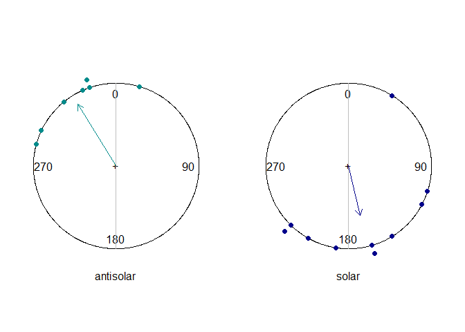

## Fit the model

In order to fit a circular model using the circular modulo and softplus links, we need to define a custom family. This family requires two `Stan` functions. One executes the circular modulo transform and the other uses this transform on estimates of $\mu$ before calculating the log-probability of data $y$ using the von Mises log-probability-density function (LPDF). Since this applies the circular modulo link function, we set the link function for $\mu$ to “identity”, and the link function for $\kappa$ to “softplus” ($\log(\exp(x)+1))$), which ensures estimates of $\kappa$ remain strictly positive.

```r
#set up required Stan functions
#circular modulo in Stan code
modulo_circular_fun = stanvar(scode = "
  real modulo_circular(real y) {
    return fmod(y + pi(), 2*pi()) - pi();
  }
",
                           block = 'functions')

#custom likelihood function using the shifted modulo link
stan_unwrap_fun = stanvar(scode = "
  real unwrap_von_mises_lpdf(real y, real mu, real kappa) {
    return von_mises_lpdf(y | modulo_circular(mu), kappa);
  }
  real unwrap_von_mises_rng(real mu, real kappa) {
    return von_mises_rng( modulo_circular(mu) , kappa);
  }
",
                          block = 'functions')
#define the custom family
unwrap_von_mises = custom_family(
  name = "unwrap_von_mises",
  dpars = c("mu",
            "kappa"),
  links = c('identity',#N.B. the link function is defined via the LPD function
            "softplus"),
  lb = c(-pi,#lower bound of mu should be -pi
         0),
  ub = c(pi,#upper bound of mu should be pi
         NA),
  type = "real",#takes continuous response data
)
```

We combine the waggle-run angles relative to the feeder (in radians) from both dances into one vector $y$, aligned with the vector $x$, which specifies whether the dance was performed under solar skylight (yes: $1$, no: $0$).

The priors follow `HS_circGLMM_fit_4cond.ipynb`: circular uniform for the $\mu$ `Intercept` (approximated as von Mises with $\kappa = 10^{-6}$), von Mises ($\mu = 0$, $\kappa = 0.5$) for the change in $\mu$, $\mathcal{N}(\mathrm{softplus}^{-1}(3), 3)$ for the $\kappa$ `Intercept` and $\mathcal{N}(0, 1)$ for the change in $\kappa$. Using the `unwrap_von_mises` LPDF for the $\mu$ priors keeps them periodic, so a change of nearly 180° in either direction is not penalised, as it would be by a $\mathcal{N}(0,\pi/2)$ prior on the linear scale.

*N.B.* By default `brms` centres predictors before fitting and then calculates the `Intercept` as `Intercept_centred - mean(x) * b_x`. For $\mu$ this breaks the circular equivalence of estimates: when `b_x` wraps around the circle by $2\pi$, the `Intercept` shifts by $2\pi$ `mean(x)`, so chains that converge to the same angles cannot be unwrapped to agree. We therefore specify the $\mu$ intercept explicitly (`y ~ 0 + Intercept + x`), which fits it without centring.

```r
dt_pair = with(hd_pair,
               data.frame(y = as.numeric(feeder_angle), #radians, -pi to pi
                          x = as.numeric(condition == 'solar')
                          )
               )

#formula for a circular model with predictor x
#mu intercept fitted without centring x, so that estimates wrap consistently
form_pair = bf(y~0 + Intercept + x,
               kappa~x,
               family = unwrap_von_mises)

#priors following HS_circGLMM_fit_4cond.ipynb
prior_pair = prior('unwrap_von_mises(0, 1e-6)', class = 'b', coef = 'Intercept') + #circular uniform
        prior('unwrap_von_mises(0, 0.5)', class = 'b', coef = 'x') + #weak bias towards no change
        prior('normal(2.95, 3)', class = 'Intercept', dpar = 'kappa') + #mean at inverse_softplus(3)
        prior('normal(0, 1)', class = 'b', dpar = 'kappa')


model_pair =  brm(formula = form_pair,
               data = dt_pair,
               family = unwrap_von_mises,
               prior = prior_pair, # the kappa and mu priors
               stanvars = stan_unwrap_fun + modulo_circular_fun,
               silent = 2,
               seed = 20250127, #date of the dances
               backend = 'cmdstan'
)
summary(model_pair)
```

```
##  Family: unwrap_von_mises
##   Links: mu = identity; kappa = softplus
## Formula: y ~ 0 + Intercept + x
##          kappa ~ x
##    Data: dt_pair (Number of observations: 17)
##   Draws: 4 chains, each with iter = 2000; warmup = 1000; thin = 1;
##          total post-warmup draws = 4000
##
## Regression Coefficients:
##                 Estimate Est.Error l-95% CI u-95% CI Rhat Bulk_ESS Tail_ESS
## kappa_Intercept     2.39      1.00     0.40     4.31 1.00     1860     2255
## Intercept           1.00      2.74    -1.09     6.08 1.53        7       33
## x                  -3.21      6.07    -9.79     4.22 1.79        6      116
## kappa_x            -0.68      0.87    -2.35     1.04 1.00     2044     1927
##
## Draws were sampled using sample(hmc). For each parameter, Bulk_ESS
## and Tail_ESS are effective sample size measures, and Rhat is the potential
## scale reduction factor on split chains (at convergence, Rhat = 1).
```

Estimates for the `Intercept` and the coefficient `b_x` (solar change in angle) wrap around the circle in different chains, so their `Rhat` values on the linear scale are high. If we unwrap these estimates, we can confirm that they converged towards the same angle, even if they moved in different directions.

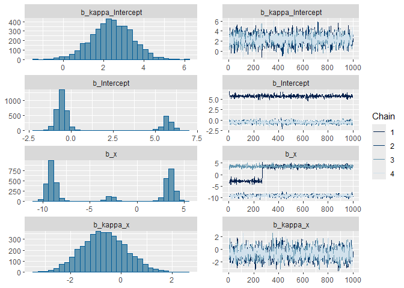

```r
plot(model_pair)
```

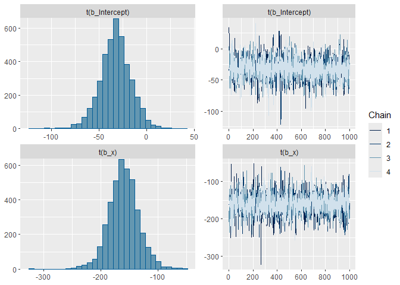

```r
#unwrap estimates and convert to degrees
plot(x = model_pair,
     variable = c('b_Intercept','b_x'),
     transform = unwrap_circular_deg)
```

```r
#print the rhat for unwrapped estimates
UnwrapRhats(model_pair,
            variable = c('b_Intercept','b_x'),
            regex = FALSE
            )
```

```
## b_Intercept         b_x
##     1.00106     1.00082
```

## Inspect predictions

To inspect the model predictions, we need to apply the model formula to the estimates. For the antisolar dance we use estimates of `b_Intercept` ($\mu$) and `b_kappa_Intercept`, and for the solar dance `b_Intercept` + `b_x` (effect of solar skylight on $\mu$) and `b_kappa_Intercept` + `b_kappa_x` (effect of solar skylight on $\kappa$). *N.B.* `Intercept_kappa` is the intercept for centred `x` (the average dance), so we use the uncentred `b_kappa_Intercept` instead. The thick arrow in each condition’s colour shows the observed mean vector, and the thin arrow shows the median model estimate.

```r
draws_pair = as_draws_df(model_pair)
#model terms for mu and kappa in each condition
pair_mu = list(antisolar = 'b_Intercept',
               solar = 'b_Intercept+b_x')
pair_kappa = list(antisolar = 'b_kappa_Intercept',
                  solar = 'b_kappa_Intercept+b_kappa_x')

par(pty = 's')
par(mar = c(0,0,0,0),
    mfrow = c(1,3))
for(cnd in pair_conds)
{
  cd_cnd = circular(x = subset(hd_pair, condition == cnd)$angle_deg,
                    units = 'degrees',
                    rotation = 'clock',
                    zero = pi/2)
  PCfun(cd_cnd,
        col = cond_cols[[cnd]],
        shrink = 1.25,
        title = cnd,
        titleline = -1,
        plot_rho = FALSE)
  Draws2Cont(draws_pair,
             x_string = paste0('sin(', pair_mu[[cnd]], ')*A1(softplus(', pair_kappa[[cnd]], '))'),
             y_string = paste0('cos(', pair_mu[[cnd]], ')*A1(softplus(', pair_kappa[[cnd]], '))')
  )
  #observed mean vector
  arrows.circular(x = mean.circular(cd_cnd),
                  y = rho.circular(cd_cnd),
                  col = cond_cols[[cnd]],
                  lwd = 5,
                  length = 0.1/1.25
  )
  #median model estimate
  with(draws_pair,
       arrows.circular(x = median.circular(x =
                               circular(mod_circular(eval(str2lang(pair_mu[[cnd]]))), #wrap to (-pi, pi) first
                                    rotation = 'clock',
                                    zero = pi/2)
                                    ),
                       y = A1(softplus(x = median(x = eval(str2lang(pair_kappa[[cnd]]))))),
                       lwd = 2,
                       length = 0.1/1.25,
                       col = adjustcolor(col_sd, alpha.f = 200/255))
  )
}

with(draws_pair, paste0(mean(mod_circular(b_x) > 0)*100, '%') ) #estimates suggesting a rightwards (clockwise) turn under solar skylight
```

```
## [1] "20.525%"
```

```r
with(draws_pair, paste0( round(
                        deg(median.circular(x =
                             circular(mod_circular(b_x), #wrap to (-pi, pi) first
                                  template = 'none')
                                  )
                            ) ),
                            '°')
     ) #median change in mean angle
```

```
## [1] "-160°"
```

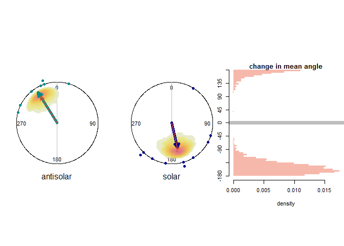

```r
with(draws_pair,
     VertHist(data = Mod360.180(deg(b_x)),
              main = 'change in mean angle',
              ylim = c(-180, 180),
              col = adjustcolor(col_sd, alpha.f = 100/255),
              axes = F,
              cex.axis = 0.7))
abline(h = 0,
       col = 'gray',
       lwd = 7)
axis(1)
axis(2, at = -4:4*45)
```

The change in concentration can be inspected in the same way, by converting estimates for each condition to the $\kappa$ scale using the `softplus` transform.

```r
with(draws_pair,
     {
       kappa_antisolar = softplus(b_kappa_Intercept)
       kappa_solar = softplus(b_kappa_Intercept + b_kappa_x)
       print(
         rbind(antisolar = quantile(kappa_antisolar, probs = c(0.025, 0.5, 0.975)),
               solar = quantile(kappa_solar, probs = c(0.025, 0.5, 0.975)),
               `solar - antisolar` = quantile(kappa_solar - kappa_antisolar,
                                              probs = c(0.025, 0.5, 0.975))
               ),
         digits = 3
       )
       paste0(mean(kappa_solar < kappa_antisolar)*100, '%') #estimates suggesting lower concentration under solar skylight
     }
)
```

```
##                     2.5%    50% 97.5%
## antisolar          0.911  2.478 4.322
## solar              0.727  1.870 3.400
## solar - antisolar -2.110 -0.582 0.828
```

```
## [1] "77.95%"
```